Skip to main content

# Exploratory Data Analysis - Customer Churn

Analisis Karakteristik dan Perilaku Pelanggan

Author

Jesen

Published

November 15, 2026

# 1 Data Preparation

## 1.1 Import Library dan Dataset

Pada tahap awal, dilakukan import library yang dibutuhkan untuk proses pengolahan data dan visualisasi. Dataset customer churn diperoleh dari repositori GitHub.

**Tampilkan / Sembunyikan Kode**

```r
library(dplyr)
library(ggplot2)
library(tidyr)
library(scales)
```

**Tampilkan / Sembunyikan Kode**

```r
# Import data dari GitHub
customer_churn <- read.csv(
  "https://raw.githubusercontent.com/Muhammadrizkybagas/bookdown-template/refs/heads/main/data/customer_churn.csv"
)

# Melihat data
head(customer_churn)
```

```
  customer_id signup_date             region segment contract_type
1  CUST-00001  2024-12-02           Sulawesi    UMKM       Bulanan
2  CUST-00002  2024-05-29           Sumatera  Retail       Bulanan
3  CUST-00003  2024-12-05           Sulawesi  Retail       Tahunan
4  CUST-00004  2023-07-21         Kalimantan    UMKM       Bulanan
5  CUST-00005  2025-05-03               Jawa  Retail       Bulanan
6  CUST-00006  2023-10-13 Bali-Nusa Tenggara    UMKM       Bulanan
   payment_method internet_service tenure_months monthly_charges total_charges
1 Virtual Account              DSL             9          373000       3231000
2   Transfer Bank            Fiber            13          345000       4419000
3    Kartu Kredit            Fiber            44          471000            NA
4   Transfer Bank Mobile Broadband             4          555000       2296000
5   Transfer Bank            Fiber             4          340000            NA
6        E-Wallet            Fiber            11          597000       6351000
  num_complaints support_calls churn
1              3             6     1
2              4             5     1
3              2             3     0
4              0             2     1
5              1             1     0
6              0             0     0
```

## 1.2 Data Cleaning

Proses cleaning dilakukan untuk memastikan data memiliki format yang sesuai sebelum dianalisis.

**Tampilkan / Sembunyikan Kode**

```r
customer_churn <- customer_churn %>%
  mutate(
    across(where(is.character), trimws),
    signup_date = as.Date(signup_date),
    region = as.factor(region),
    segment = as.factor(segment),
    contract_type = as.factor(contract_type),
    payment_method = as.factor(payment_method),
    internet_service = as.factor(internet_service),
    churn = factor(churn, levels = c(0, 1),
                   labels = c("Tidak Churn", "Churn"))
  ) %>%
  distinct(customer_id, .keep_all = TRUE)
```

## 1.3 Pemeriksaan Data

**Tampilkan / Sembunyikan Kode**

```r
# Struktur data
str(customer_churn)
```

```
'data.frame':   3000 obs. of  13 variables:
 $ customer_id     : chr  "CUST-00001" "CUST-00002" "CUST-00003" "CUST-00004" ...
 $ signup_date     : Date, format: "2024-12-02" "2024-05-29" ...
 $ region          : Factor w/ 5 levels "Bali-Nusa Tenggara",..: 4 5 4 3 2 1 4 4 2 5 ...
 $ segment         : Factor w/ 3 levels "Korporat","Retail",..: 3 2 2 3 2 3 2 2 2 3 ...
 $ contract_type   : Factor w/ 3 levels "Bulanan","Dua Tahun",..: 1 1 3 1 1 1 3 2 3 2 ...
 $ payment_method  : Factor w/ 4 levels "E-Wallet","Kartu Kredit",..: 4 3 2 3 3 1 3 1 1 3 ...
 $ internet_service: Factor w/ 3 levels "DSL","Fiber",..: 1 2 2 3 2 2 2 3 1 2 ...
 $ tenure_months   : int  9 13 44 4 4 11 20 33 34 63 ...
 $ monthly_charges : num  373000 345000 471000 555000 340000 597000 371000 435000 308000 591000 ...
 $ total_charges   : num  3231000 4419000 NA 2296000 NA ...
 $ num_complaints  : int  3 4 2 0 1 0 1 2 1 1 ...
 $ support_calls   : int  6 5 3 2 1 0 3 6 1 1 ...
 $ churn           : Factor w/ 2 levels "Tidak Churn",..: 2 2 1 2 1 1 1 1 1 1 ...
```

**Tampilkan / Sembunyikan Kode**

```r
# Dimensi data
dim(customer_churn)
```

```
[1] 3000   13
```

**Tampilkan / Sembunyikan Kode**

```r
# Missing value setiap kolom
colSums(is.na(customer_churn))
```

```
     customer_id      signup_date           region          segment
               0                0                0                0
   contract_type   payment_method internet_service    tenure_months
               0                0                0                0
 monthly_charges    total_charges   num_complaints    support_calls
               0               45                0                0
           churn
               0
```

**Tampilkan / Sembunyikan Kode**

```r
# Total missing value
sum(is.na(customer_churn))
```

```
[1] 45
```

**Tampilkan / Sembunyikan Kode**

```r
# Duplikasi ID pelanggan
sum(duplicated(customer_churn$customer_id))
```

```
[1] 0
```

**Tampilkan / Sembunyikan Kode**

```r
# Statistik deskriptif
summary(customer_churn)
```

```
    customer_id    signup_date                        region
 Length   :3000   Min.   :2023-01-01   Bali-Nusa Tenggara: 306
 N.unique :3000   1st Qu.:2023-10-09   Jawa              :1262
 N.blank  :   0   Median :2024-06-27   Kalimantan        : 332
 Min.nchar:  10   Mean   :2024-07-02   Sulawesi          : 430
 Max.nchar:  10   3rd Qu.:2025-04-03   Sumatera          : 670
                  Max.   :2025-12-30

     segment       contract_type          payment_method
 Korporat: 321   Bulanan  :1541   E-Wallet       :862
 Retail  :1836   Dua Tahun: 536   Kartu Kredit   :653
 UMKM    : 843   Tahunan  : 923   Transfer Bank  :901
                                  Virtual Account:584



         internet_service tenure_months   monthly_charges   total_charges
 DSL             : 926    Min.   : 1.00   Min.   : 160000   Min.   :  214000
 Fiber           :1431    1st Qu.:13.00   1st Qu.: 304000   1st Qu.: 5127000
 Mobile Broadband: 643    Median :25.00   Median : 393000   Median : 9231000
                          Mean   :26.52   Mean   : 423952   Mean   :11296852
                          3rd Qu.:35.00   3rd Qu.: 497250   3rd Qu.:15236500
                          Max.   :71.00   Max.   :1353000   Max.   :59536000
                                                            NAs    :45
 num_complaints  support_calls            churn
 Min.   :0.000   Min.   : 0.000   Tidak Churn:1952
 1st Qu.:0.000   1st Qu.: 1.000   Churn      :1048
 Median :1.000   Median : 2.000
 Mean   :1.128   Mean   : 2.429
 3rd Qu.:2.000   3rd Qu.: 3.000
 Max.   :7.000   Max.   :13.000
```

## 1.4 Persiapan Variabel Analisis

Membuat variabel numerik churn untuk kebutuhan perhitungan tingkat churn dan korelasi.

**Tampilkan / Sembunyikan Kode**

```r
customer_churn <- customer_churn %>%
  mutate(
    churn_num = as.integer(churn == "Churn")
  )
```

# 2 Overview Dataset

Bagian ini memberikan gambaran umum mengenai karakteristik dataset dan kondisi pelanggan.

## 2.1 Informasi Dataset

**Tampilkan / Sembunyikan Kode**

```r
cat("Jumlah Pelanggan:", nrow(customer_churn), "\n")
```

```
Jumlah Pelanggan: 3000
```

**Tampilkan / Sembunyikan Kode**

```r
cat("Jumlah Variabel:", ncol(customer_churn), "\n")
```

```
Jumlah Variabel: 14
```

**Tampilkan / Sembunyikan Kode**

```r
cat("Tanggal Pendaftaran Terawal:", min(customer_churn$signup_date), "\n")
```

```
Tanggal Pendaftaran Terawal: 19358
```

**Tampilkan / Sembunyikan Kode**

```r
cat("Tanggal Pendaftaran Terakhir:", max(customer_churn$signup_date), "\n")
```

```
Tanggal Pendaftaran Terakhir: 20452
```

**Tampilkan / Sembunyikan Kode**

```r
cat("Total Missing Value:", sum(is.na(customer_churn)), "\n")
```

```
Total Missing Value: 45
```

## 2.2 Key Performance Indicators (KPI)

**Tampilkan / Sembunyikan Kode**

```r
total_customer <- nrow(customer_churn)

total_churn <- sum(customer_churn$churn == "Churn")

total_stay <- sum(customer_churn$churn == "Tidak Churn")

churn_rate <- total_churn / total_customer

stay_rate <- total_stay / total_customer

kpi <- data.frame(
  Metric = c(
    "Total Customer",
    "Customer Churn",
    "Customer Retained",
    "Churn Rate",
    "Retention Rate"
  ),
  Value = c(
    total_customer,
    total_churn,
    total_stay,
    percent(churn_rate),
    percent(stay_rate)
  )
)

knitr::kable(kpi, caption = "Customer Overview")
```

Customer Overview

| Metric | Value |
| --- | --- |
| Total Customer | 3000 |
| Customer Churn | 1048 |
| Customer Retained | 1952 |
| Churn Rate | 35% |
| Retention Rate | 65% |

## 2.3 Distribusi Status Pelanggan

Visualisasi ini digunakan untuk mengetahui perbandingan pelanggan yang masih berlangganan dan pelanggan yang berhenti berlangganan.

**Tampilkan / Sembunyikan Kode**

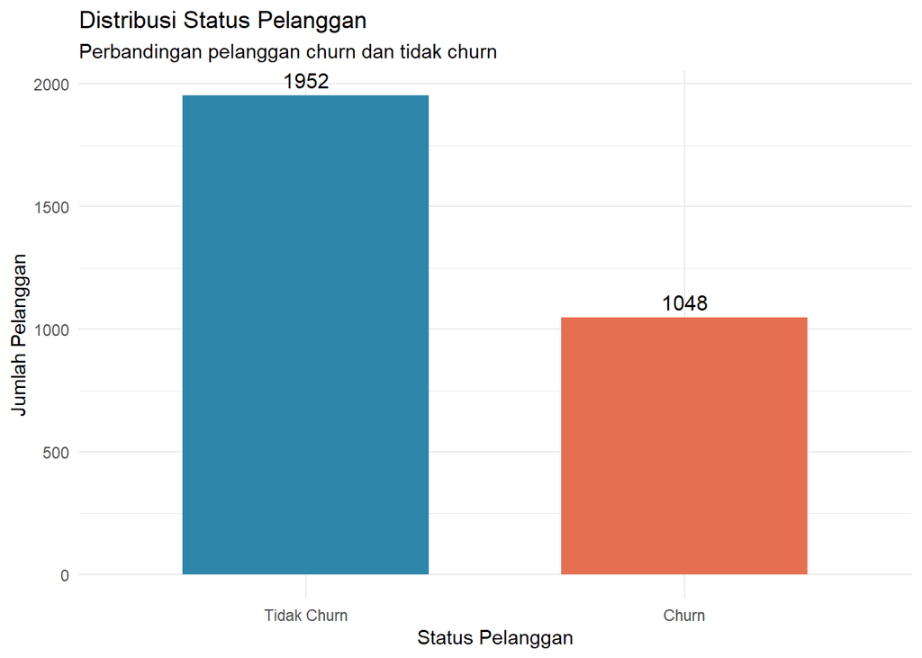

```r
ggplot(customer_churn, aes(x = churn, fill = churn)) +
  geom_bar(width = 0.65) +
  geom_text(
    stat = "count",
    aes(label = after_stat(count)),
    vjust = -0.5,
    size = 4
  ) +
  scale_fill_manual(
    values = c("Tidak Churn" = "#2E86AB",
               "Churn" = "#E76F51")
  ) +
  labs(
    title = "Distribusi Status Pelanggan",
    subtitle = "Perbandingan pelanggan churn dan tidak churn",
    x = "Status Pelanggan",
    y = "Jumlah Pelanggan"
  ) +
  theme_minimal() +
  theme(legend.position = "none")
```

## 2.4 Proporsi Status Pelanggan

**Tampilkan / Sembunyikan Kode**

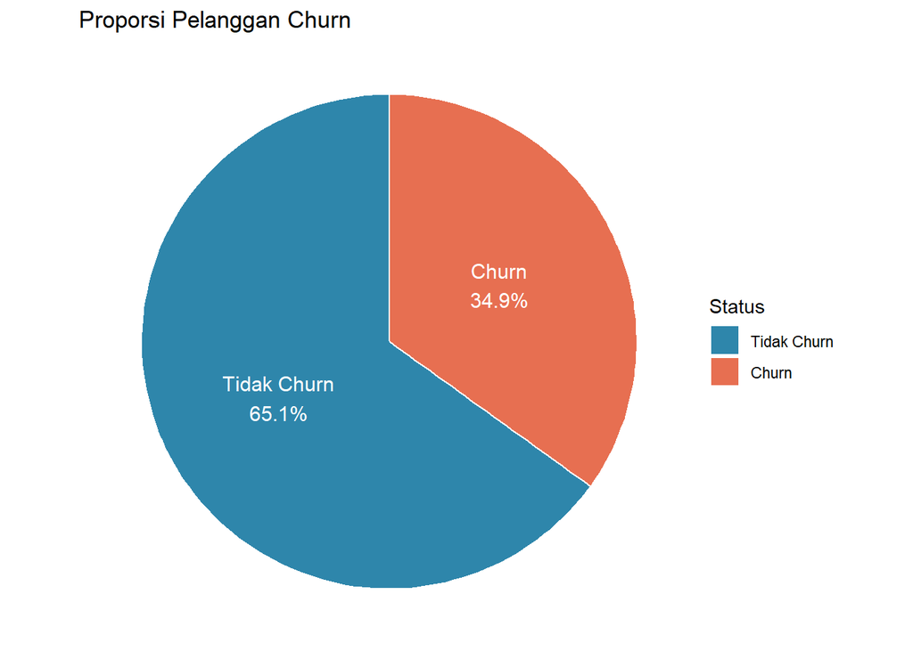

```r
churn_distribution <- customer_churn %>%
  count(churn) %>%
  mutate(
    percentage = n / sum(n),
    label = paste0(
      churn, "\n",
      percent(percentage, accuracy = 0.1)
    )
  )

ggplot(churn_distribution,
       aes(x = "", y = percentage, fill = churn)) +
  geom_col(width = 1, color = "white") +
  coord_polar(theta = "y") +
  geom_text(
    aes(label = label),
    position = position_stack(vjust = 0.5),
    color = "white",
    size = 4
  ) +
  scale_fill_manual(
    values = c("Tidak Churn" = "#2E86AB",
               "Churn" = "#E76F51")
  ) +
  labs(
    title = "Proporsi Pelanggan Churn",
    fill = "Status"
  ) +
  theme_void()
```

# 3 Customer Demographics and Segmentation

Bagian ini menganalisis karakteristik pelanggan berdasarkan wilayah dan jenis segmen pelanggan.

## 3.1 Distribusi Pelanggan Berdasarkan Wilayah

**Tampilkan / Sembunyikan Kode**

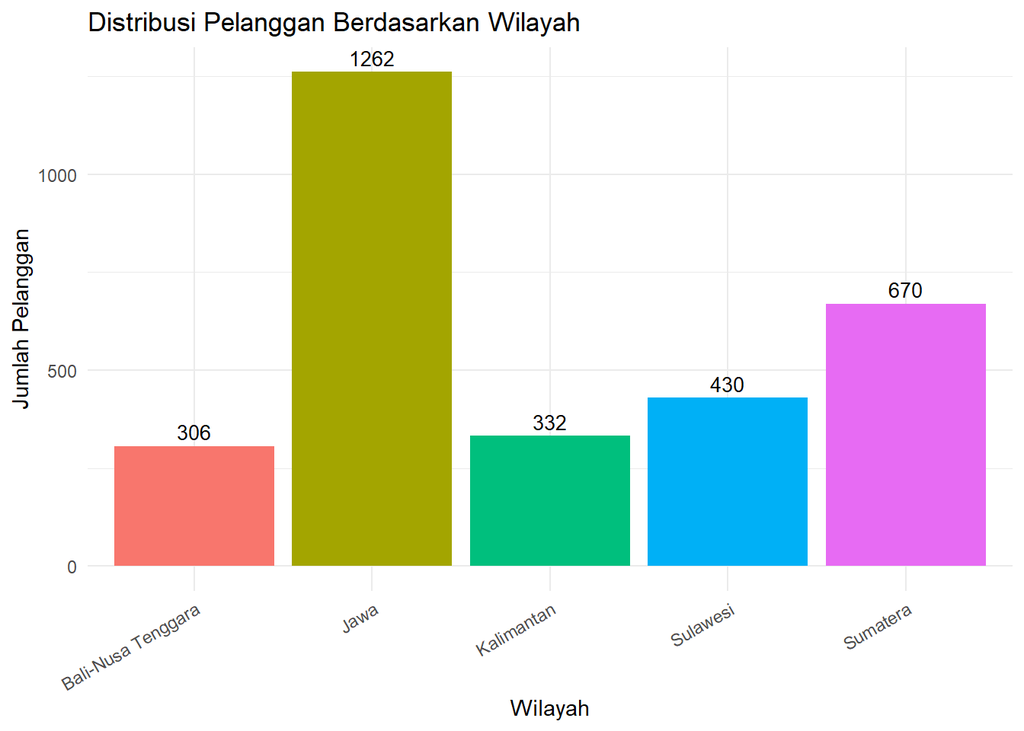

```r
ggplot(customer_churn, aes(x = region, fill = region)) +
  geom_bar() +
  geom_text(
    stat = "count",
    aes(label = after_stat(count)),
    vjust = -0.4,
    size = 3.5
  ) +
  labs(
    title = "Distribusi Pelanggan Berdasarkan Wilayah",
    x = "Wilayah",
    y = "Jumlah Pelanggan"
  ) +
  theme_minimal() +
  theme(
    legend.position = "none",
    axis.text.x = element_text(angle = 30, hjust = 1)
  )
```

## 3.2 Distribusi Pelanggan Berdasarkan Segmen

**Tampilkan / Sembunyikan Kode**

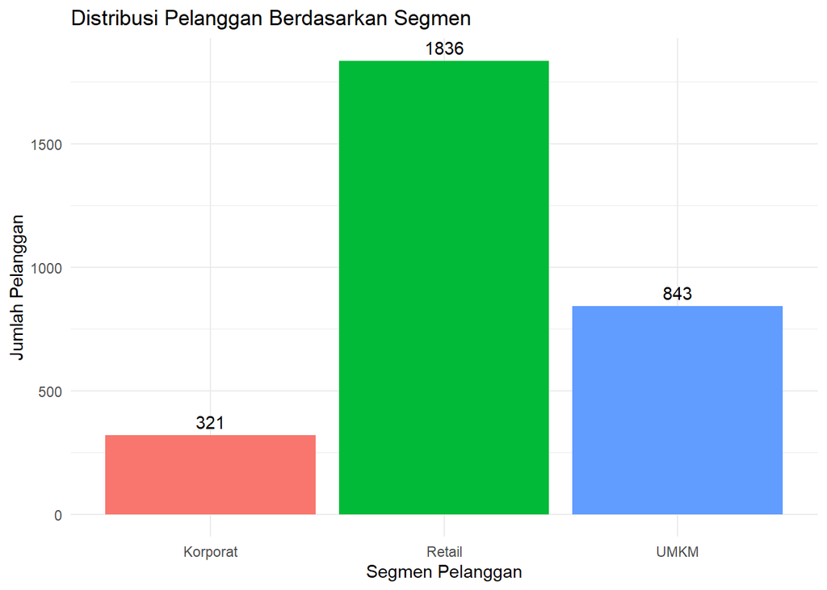

```r
ggplot(customer_churn, aes(x = segment, fill = segment)) +
  geom_bar() +
  geom_text(
    stat = "count",
    aes(label = after_stat(count)),
    vjust = -0.5
  ) +
  labs(
    title = "Distribusi Pelanggan Berdasarkan Segmen",
    x = "Segmen Pelanggan",
    y = "Jumlah Pelanggan"
  ) +
  theme_minimal() +
  theme(legend.position = "none")
```

## 3.3 Perbandingan Churn Berdasarkan Wilayah

**Tampilkan / Sembunyikan Kode**

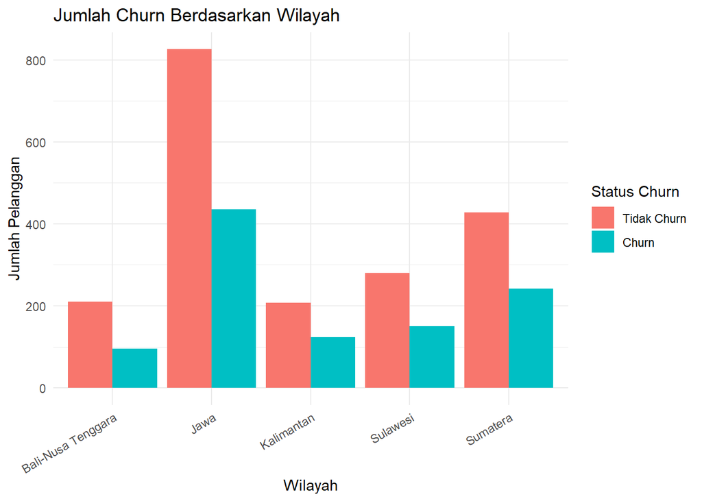

```r
ggplot(customer_churn, aes(x = region, fill = churn)) +
  geom_bar(position = "dodge") +
  labs(
    title = "Jumlah Churn Berdasarkan Wilayah",
    x = "Wilayah",
    y = "Jumlah Pelanggan",
    fill = "Status Churn"
  ) +
  theme_minimal() +
  theme(axis.text.x = element_text(angle = 30, hjust = 1))
```

## 3.4 Tingkat Churn Berdasarkan Wilayah

Jumlah churn saja belum cukup untuk membandingkan wilayah karena setiap wilayah memiliki jumlah pelanggan yang berbeda. Oleh karena itu, digunakan churn rate.

**Tampilkan / Sembunyikan Kode**

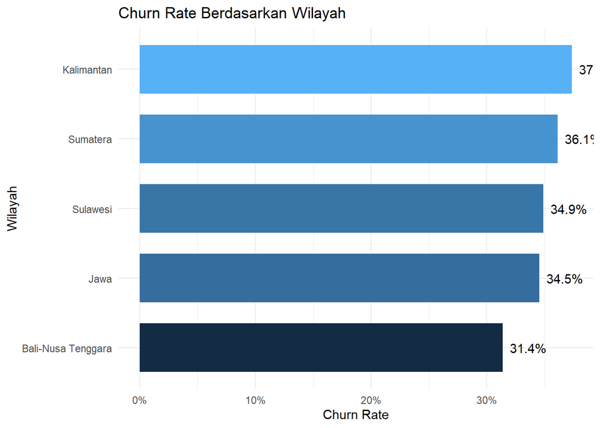

```r
region_churn <- customer_churn %>%
  group_by(region) %>%
  summarise(
    total_customer = n(),
    total_churn = sum(churn == "Churn"),
    churn_rate = total_churn / total_customer,
    .groups = "drop"
  )

ggplot(region_churn,
       aes(x = reorder(region, churn_rate),
           y = churn_rate,
           fill = churn_rate)) +
  geom_col(width = 0.7) +
  geom_text(
    aes(label = percent(churn_rate, accuracy = 0.1)),
    hjust = -0.2
  ) +
  coord_flip() +
  scale_y_continuous(labels = percent) +
  labs(
    title = "Churn Rate Berdasarkan Wilayah",
    x = "Wilayah",
    y = "Churn Rate"
  ) +
  theme_minimal() +
  theme(legend.position = "none")
```

## 3.5 Tingkat Churn Berdasarkan Segmen

**Tampilkan / Sembunyikan Kode**

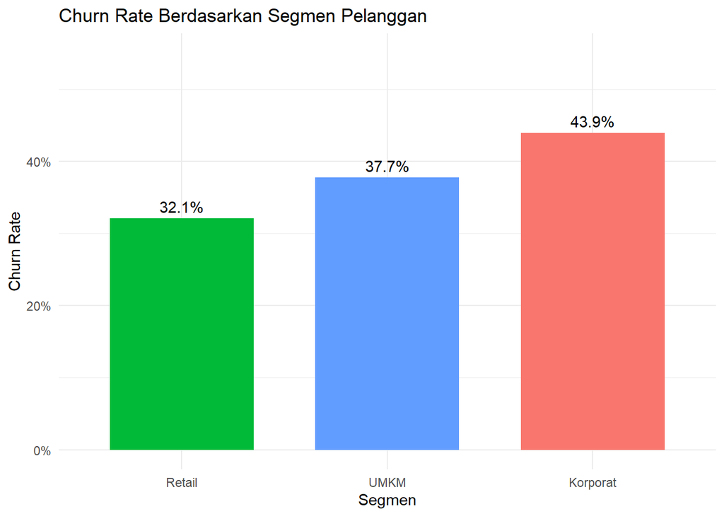

```r
segment_churn <- customer_churn %>%
  group_by(segment) %>%
  summarise(
    total_customer = n(),
    total_churn = sum(churn == "Churn"),
    churn_rate = total_churn / total_customer,
    .groups = "drop"
  )

ggplot(segment_churn,
       aes(x = reorder(segment, churn_rate),
           y = churn_rate,
           fill = segment)) +
  geom_col(width = 0.7) +
  geom_text(
    aes(label = percent(churn_rate, accuracy = 0.1)),
    vjust = -0.5
  ) +
  scale_y_continuous(
    labels = percent,
    limits = c(0, 0.55)
  ) +
  labs(
    title = "Churn Rate Berdasarkan Segmen Pelanggan",
    x = "Segmen",
    y = "Churn Rate"
  ) +
  theme_minimal() +
  theme(legend.position = "none")
```

# 4 Contract and Payment Analysis

Bagian ini bertujuan mengetahui hubungan antara jenis kontrak dan metode pembayaran dengan perilaku pelanggan.

## 4.1 Distribusi Jenis Kontrak

**Tampilkan / Sembunyikan Kode**

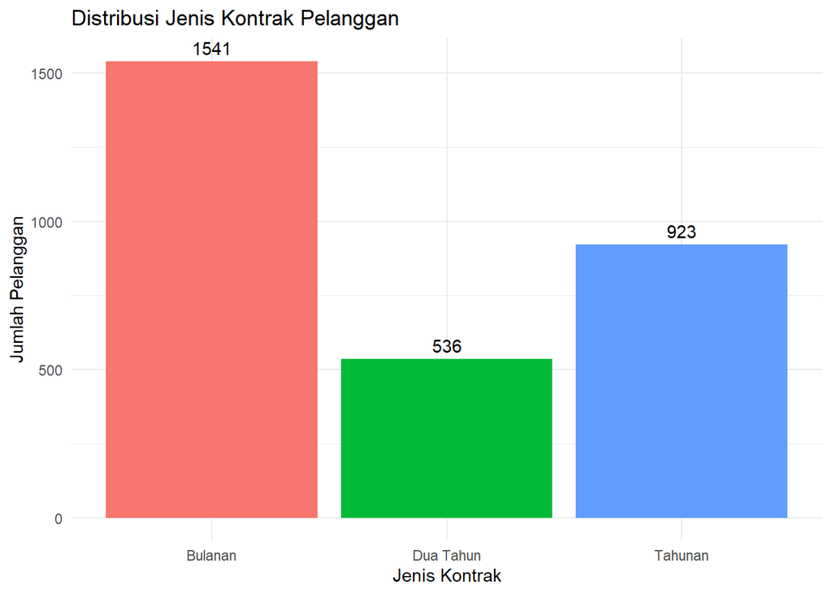

```r
ggplot(customer_churn,
       aes(x = contract_type, fill = contract_type)) +
  geom_bar() +
  geom_text(
    stat = "count",
    aes(label = after_stat(count)),
    vjust = -0.5
  ) +
  labs(
    title = "Distribusi Jenis Kontrak Pelanggan",
    x = "Jenis Kontrak",
    y = "Jumlah Pelanggan"
  ) +
  theme_minimal() +
  theme(legend.position = "none")
```

## 4.2 Churn Berdasarkan Jenis Kontrak

**Tampilkan / Sembunyikan Kode**

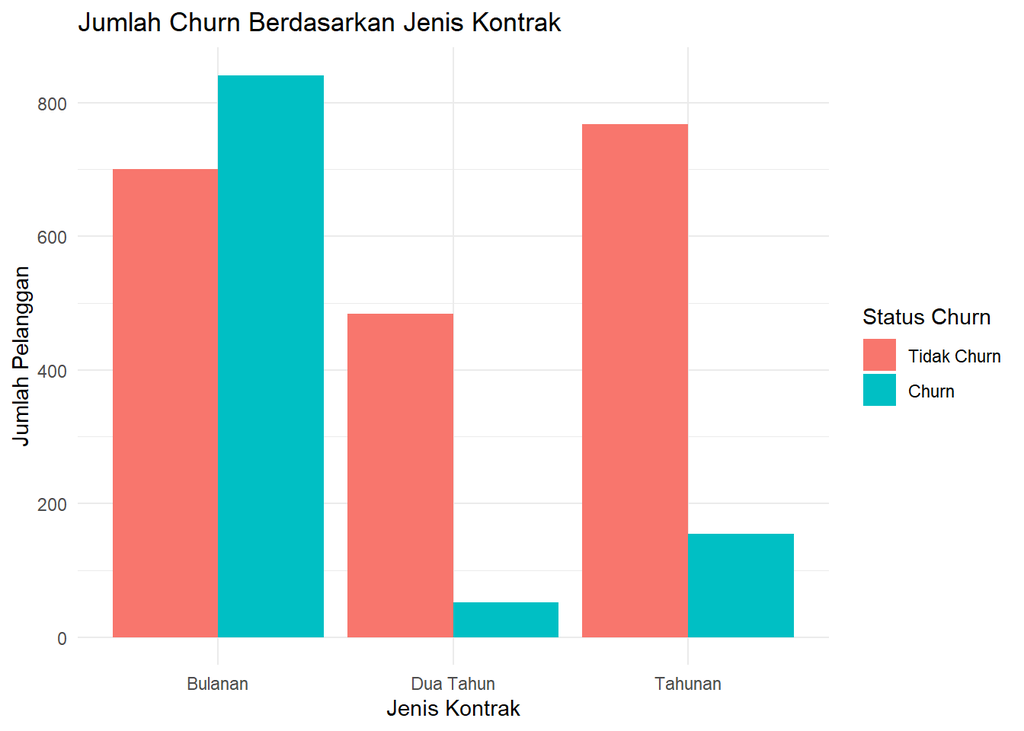

```r
ggplot(customer_churn,
       aes(x = contract_type, fill = churn)) +
  geom_bar(position = "dodge") +
  labs(
    title = "Jumlah Churn Berdasarkan Jenis Kontrak",
    x = "Jenis Kontrak",
    y = "Jumlah Pelanggan",
    fill = "Status Churn"
  ) +
  theme_minimal()
```

## 4.3 Churn Rate Berdasarkan Jenis Kontrak

**Tampilkan / Sembunyikan Kode**

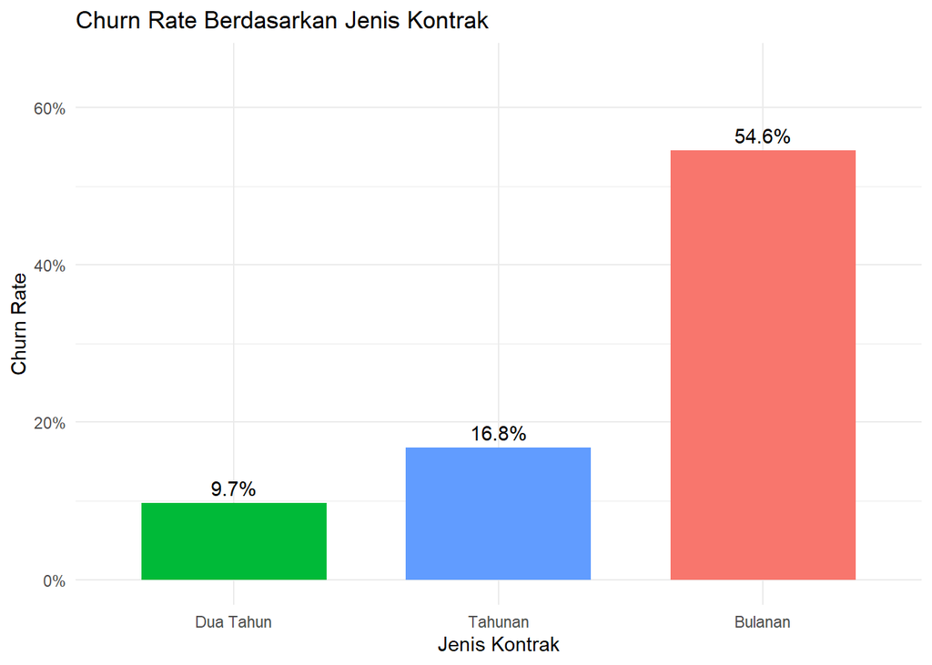

```r
contract_churn <- customer_churn %>%
  group_by(contract_type) %>%
  summarise(
    total_customer = n(),
    total_churn = sum(churn == "Churn"),
    churn_rate = total_churn / total_customer,
    .groups = "drop"
  )

ggplot(contract_churn,
       aes(x = reorder(contract_type, churn_rate),
           y = churn_rate,
           fill = contract_type)) +
  geom_col(width = 0.7) +
  geom_text(
    aes(label = percent(churn_rate, accuracy = 0.1)),
    vjust = -0.5
  ) +
  scale_y_continuous(
    labels = percent,
    limits = c(0, 0.65)
  ) +
  labs(
    title = "Churn Rate Berdasarkan Jenis Kontrak",
    x = "Jenis Kontrak",
    y = "Churn Rate"
  ) +
  theme_minimal() +
  theme(legend.position = "none")
```

## 4.4 Distribusi Metode Pembayaran

**Tampilkan / Sembunyikan Kode**

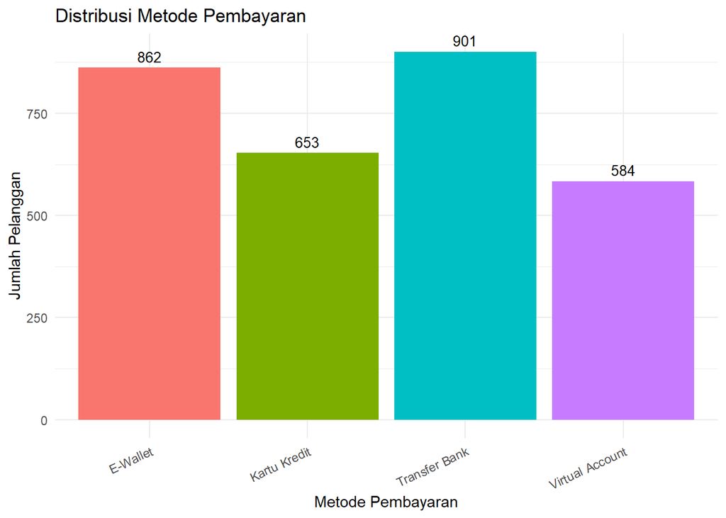

```r
ggplot(customer_churn,
       aes(x = payment_method, fill = payment_method)) +
  geom_bar() +
  geom_text(
    stat = "count",
    aes(label = after_stat(count)),
    vjust = -0.5,
    size = 3.5
  ) +
  labs(
    title = "Distribusi Metode Pembayaran",
    x = "Metode Pembayaran",
    y = "Jumlah Pelanggan"
  ) +
  theme_minimal() +
  theme(
    legend.position = "none",
    axis.text.x = element_text(angle = 25, hjust = 1)
  )
```

## 4.5 Churn Rate Berdasarkan Metode Pembayaran

**Tampilkan / Sembunyikan Kode**

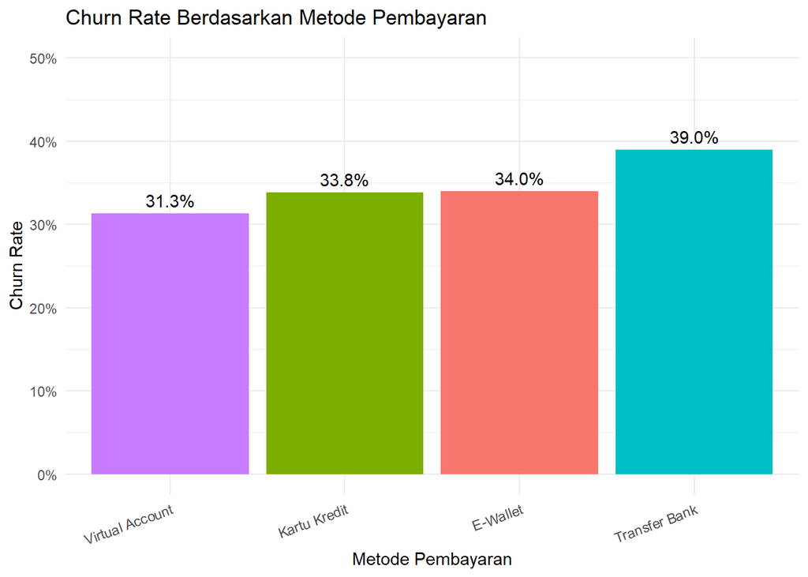

```r
payment_churn <- customer_churn %>%
  group_by(payment_method) %>%
  summarise(
    total_customer = n(),
    total_churn = sum(churn == "Churn"),
    churn_rate = total_churn / total_customer,
    .groups = "drop"
  )

ggplot(payment_churn,
       aes(x = reorder(payment_method, churn_rate),
           y = churn_rate,
           fill = payment_method)) +
  geom_col() +
  geom_text(
    aes(label = percent(churn_rate, accuracy = 0.1)),
    vjust = -0.5
  ) +
  scale_y_continuous(
    labels = percent,
    limits = c(0, 0.5)
  ) +
  labs(
    title = "Churn Rate Berdasarkan Metode Pembayaran",
    x = "Metode Pembayaran",
    y = "Churn Rate"
  ) +
  theme_minimal() +
  theme(
    legend.position = "none",
    axis.text.x = element_text(angle = 20, hjust = 1)
  )
```

# 5 Internet Service Analysis

Bagian ini membandingkan perilaku pelanggan berdasarkan jenis layanan internet yang digunakan.

## 5.1 Distribusi Layanan Internet

**Tampilkan / Sembunyikan Kode**

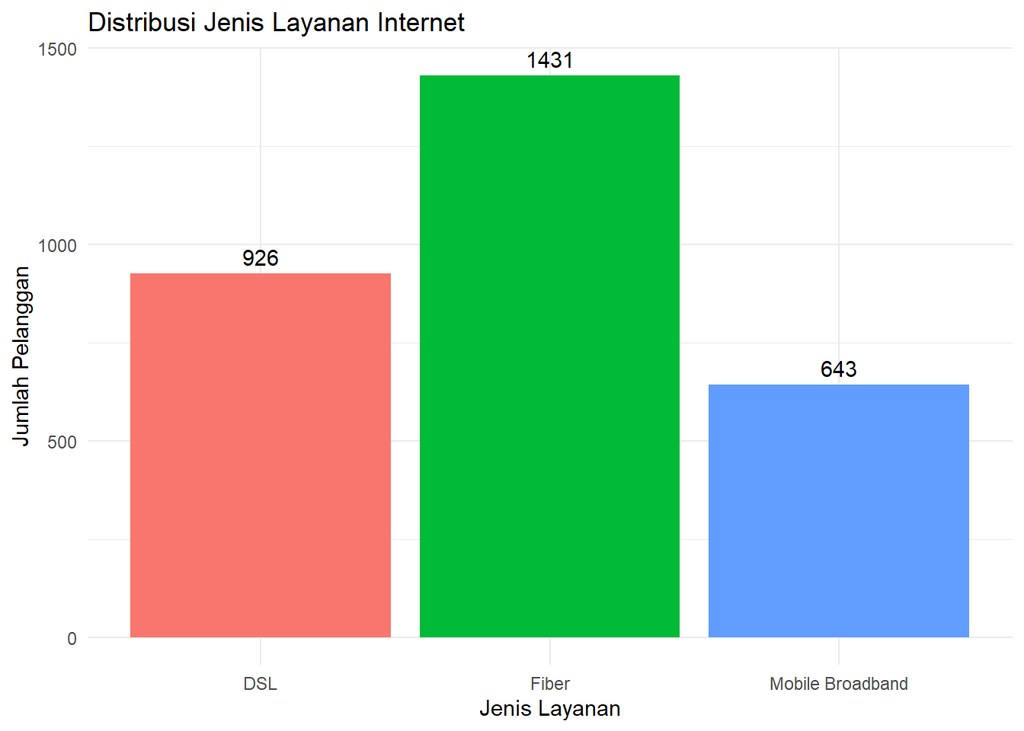

```r
ggplot(customer_churn,
       aes(x = internet_service, fill = internet_service)) +
  geom_bar() +
  geom_text(
    stat = "count",
    aes(label = after_stat(count)),
    vjust = -0.5
  ) +
  labs(
    title = "Distribusi Jenis Layanan Internet",
    x = "Jenis Layanan",
    y = "Jumlah Pelanggan"
  ) +
  theme_minimal() +
  theme(legend.position = "none")
```

## 5.2 Churn Berdasarkan Layanan Internet

**Tampilkan / Sembunyikan Kode**

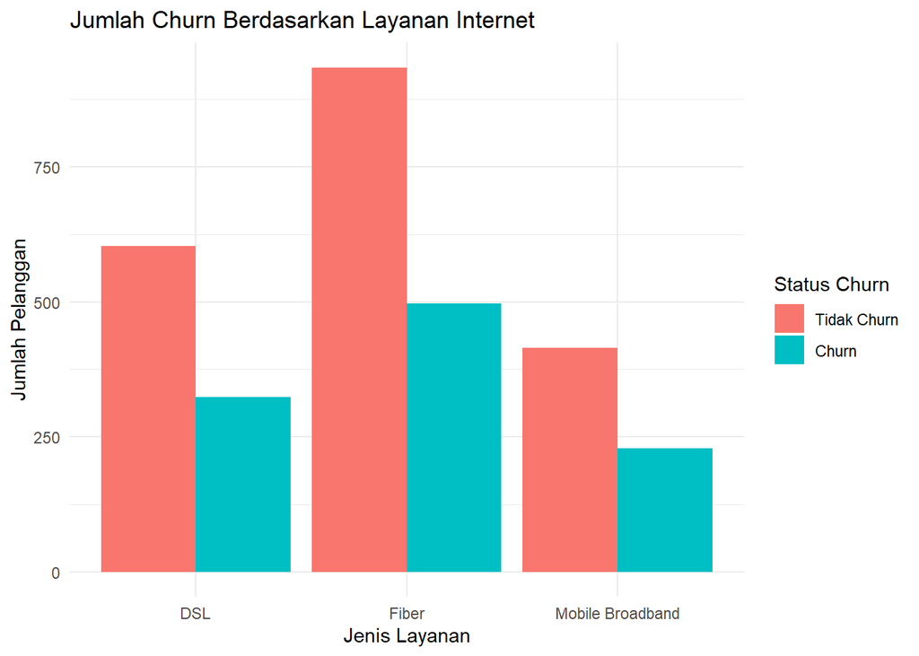

```r
ggplot(customer_churn,
       aes(x = internet_service, fill = churn)) +
  geom_bar(position = "dodge") +
  labs(
    title = "Jumlah Churn Berdasarkan Layanan Internet",
    x = "Jenis Layanan",
    y = "Jumlah Pelanggan",
    fill = "Status Churn"
  ) +
  theme_minimal()
```

## 5.3 Churn Rate Berdasarkan Layanan Internet

**Tampilkan / Sembunyikan Kode**

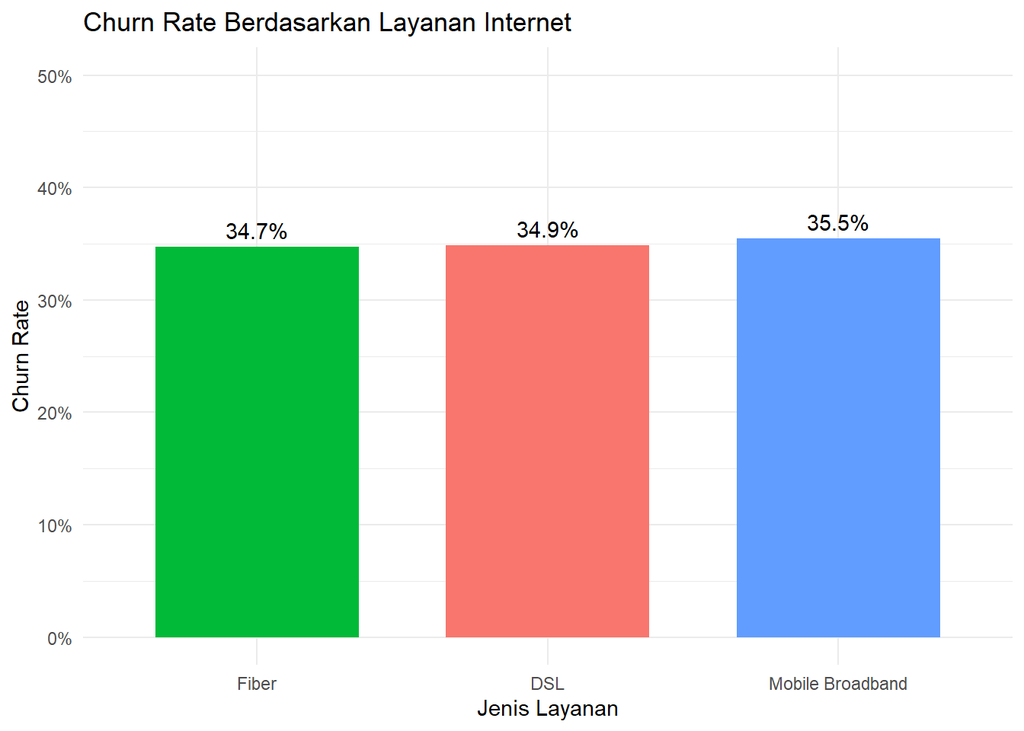

```r
service_churn <- customer_churn %>%
  group_by(internet_service) %>%
  summarise(
    total_customer = n(),
    total_churn = sum(churn == "Churn"),
    churn_rate = total_churn / total_customer,
    .groups = "drop"
  )

ggplot(service_churn,
       aes(x = reorder(internet_service, churn_rate),
           y = churn_rate,
           fill = internet_service)) +
  geom_col(width = 0.7) +
  geom_text(
    aes(label = percent(churn_rate, accuracy = 0.1)),
    vjust = -0.5
  ) +
  scale_y_continuous(
    labels = percent,
    limits = c(0, 0.5)
  ) +
  labs(
    title = "Churn Rate Berdasarkan Layanan Internet",
    x = "Jenis Layanan",
    y = "Churn Rate"
  ) +
  theme_minimal() +
  theme(legend.position = "none")
```

# 6 Customer Registration Trend

Bagian ini menganalisis perkembangan jumlah pelanggan berdasarkan tanggal pendaftaran.

## 6.1 Tren Pendaftaran Pelanggan

**Tampilkan / Sembunyikan Kode**

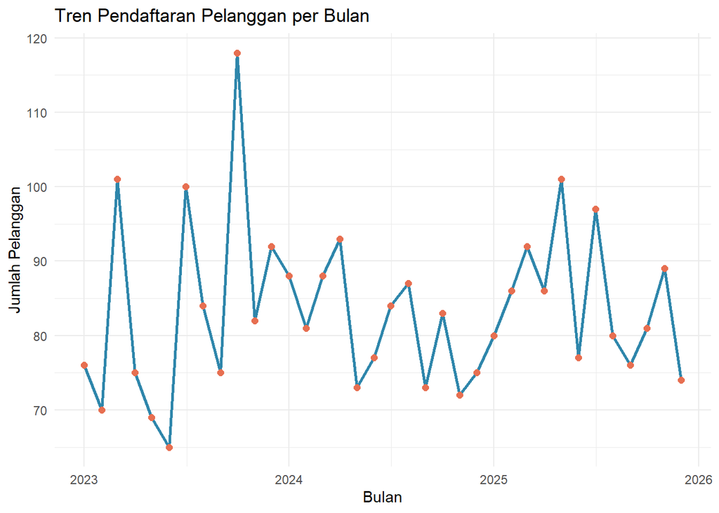

```r
monthly_signup <- customer_churn %>%
  mutate(
    month = as.Date(format(signup_date, "%Y-%m-01"))
  ) %>%
  group_by(month) %>%
  summarise(
    total_customer = n(),
    .groups = "drop"
  )

ggplot(monthly_signup,
       aes(x = month, y = total_customer)) +
  geom_line(color = "#2E86AB", linewidth = 1) +
  geom_point(color = "#E76F51", size = 2) +
  labs(
    title = "Tren Pendaftaran Pelanggan per Bulan",
    x = "Bulan",
    y = "Jumlah Pelanggan"
  ) +
  theme_minimal()
```

## 6.2 Tren Churn Berdasarkan Bulan Pendaftaran

Visualisasi ini melihat persentase pelanggan yang mengalami churn berdasarkan bulan ketika mereka mendaftar.

**Tampilkan / Sembunyikan Kode**

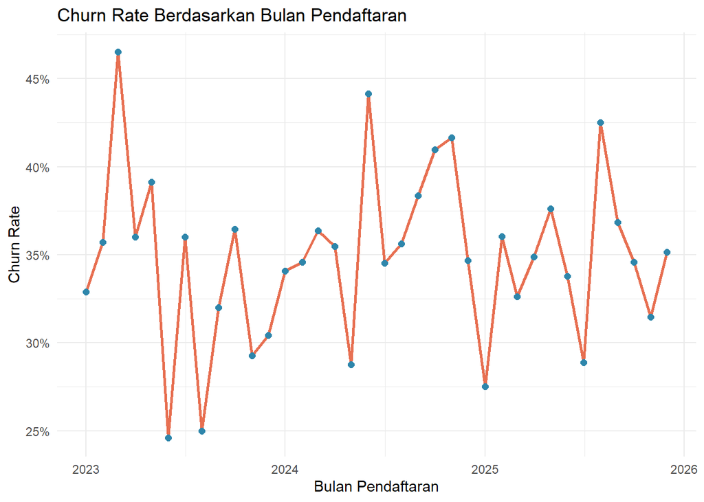

```r
monthly_churn <- customer_churn %>%
  mutate(
    month = as.Date(format(signup_date, "%Y-%m-01"))
  ) %>%
  group_by(month) %>%
  summarise(
    total_customer = n(),
    total_churn = sum(churn == "Churn"),
    churn_rate = total_churn / total_customer,
    .groups = "drop"
  )

ggplot(monthly_churn,
       aes(x = month, y = churn_rate)) +
  geom_line(color = "#E76F51", linewidth = 1) +
  geom_point(color = "#2E86AB", size = 2) +
  scale_y_continuous(labels = percent) +
  labs(
    title = "Churn Rate Berdasarkan Bulan Pendaftaran",
    x = "Bulan Pendaftaran",
    y = "Churn Rate"
  ) +
  theme_minimal()
```

# 7 Customer Tenure Analysis

Tenure merupakan lama waktu pelanggan telah berlangganan dalam satuan bulan.

## 7.1 Distribusi Tenure Pelanggan

**Tampilkan / Sembunyikan Kode**

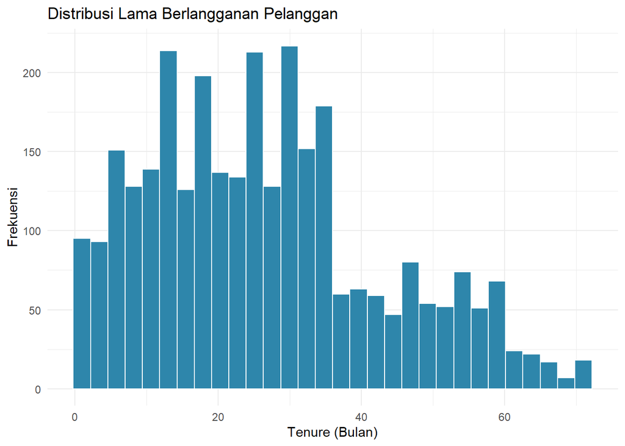

```r
ggplot(customer_churn,
       aes(x = tenure_months)) +
  geom_histogram(
    bins = 30,
    fill = "#2E86AB",
    color = "white"
  ) +
  labs(
    title = "Distribusi Lama Berlangganan Pelanggan",
    x = "Tenure (Bulan)",
    y = "Frekuensi"
  ) +
  theme_minimal()
```

## 7.2 Distribusi Tenure Berdasarkan Status Churn

**Tampilkan / Sembunyikan Kode**

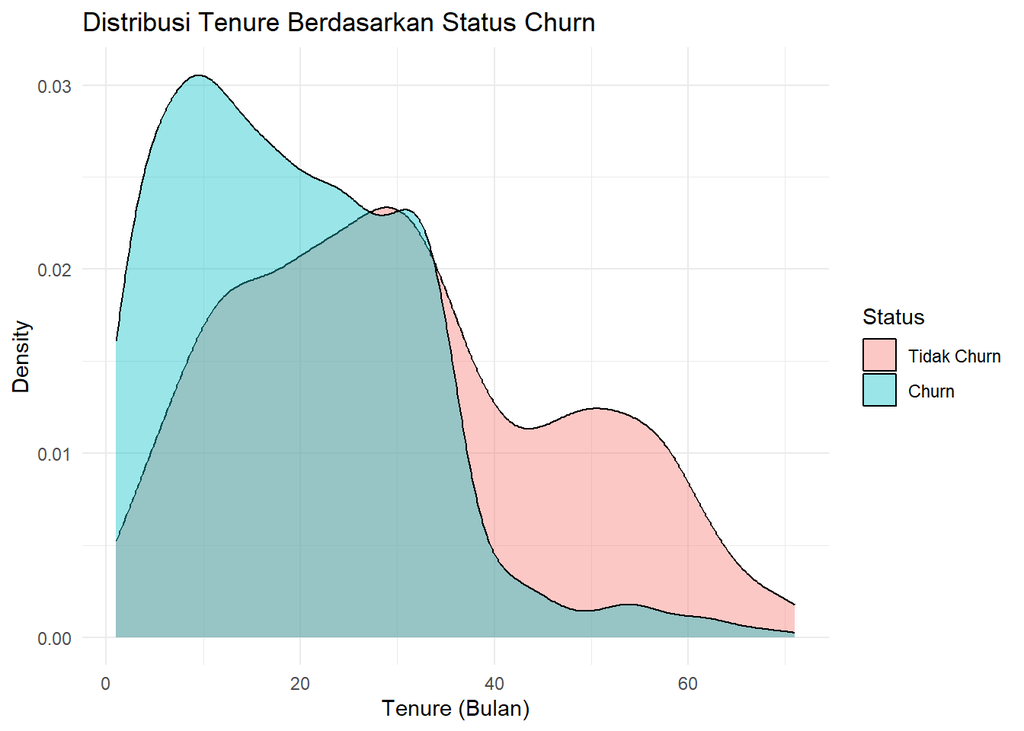

```r
ggplot(customer_churn,
       aes(x = tenure_months, fill = churn)) +
  geom_density(alpha = 0.4) +
  labs(
    title = "Distribusi Tenure Berdasarkan Status Churn",
    x = "Tenure (Bulan)",
    y = "Density",
    fill = "Status"
  ) +
  theme_minimal()
```

## 7.3 Perbandingan Tenure dengan Boxplot

**Tampilkan / Sembunyikan Kode**

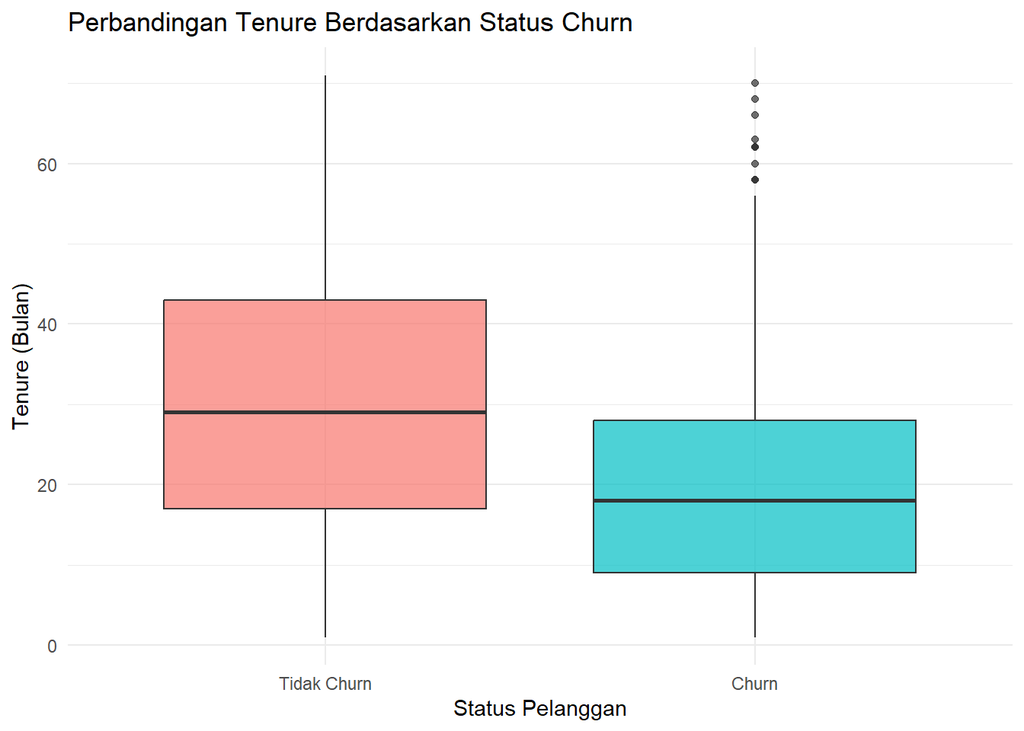

```r
ggplot(customer_churn,
       aes(x = churn, y = tenure_months, fill = churn)) +
  geom_boxplot(alpha = 0.7) +
  labs(
    title = "Perbandingan Tenure Berdasarkan Status Churn",
    x = "Status Pelanggan",
    y = "Tenure (Bulan)"
  ) +
  theme_minimal() +
  theme(legend.position = "none")
```

## 7.4 Churn Rate Berdasarkan Kelompok Tenure

**Tampilkan / Sembunyikan Kode**

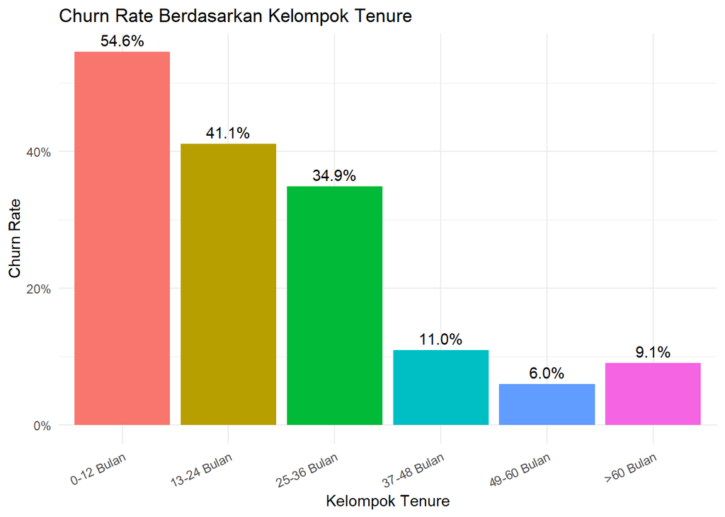

```r
tenure_churn <- customer_churn %>%
  mutate(
    tenure_group = cut(
      tenure_months,
      breaks = c(0, 12, 24, 36, 48, 60, Inf),
      labels = c(
        "0-12 Bulan",
        "13-24 Bulan",
        "25-36 Bulan",
        "37-48 Bulan",
        "49-60 Bulan",
        ">60 Bulan"
      )
    )
  ) %>%
  group_by(tenure_group) %>%
  summarise(
    total_customer = n(),
    total_churn = sum(churn == "Churn"),
    churn_rate = total_churn / total_customer,
    .groups = "drop"
  )

ggplot(tenure_churn,
       aes(x = tenure_group, y = churn_rate, fill = tenure_group)) +
  geom_col() +
  geom_text(
    aes(label = percent(churn_rate, accuracy = 0.1)),
    vjust = -0.5
  ) +
  scale_y_continuous(labels = percent) +
  labs(
    title = "Churn Rate Berdasarkan Kelompok Tenure",
    x = "Kelompok Tenure",
    y = "Churn Rate"
  ) +
  theme_minimal() +
  theme(
    legend.position = "none",
    axis.text.x = element_text(angle = 25, hjust = 1)
  )
```

# 8 Financial Analysis

Bagian ini menganalisis biaya yang dikeluarkan pelanggan selama berlangganan.

## 8.1 Distribusi Biaya Bulanan

**Tampilkan / Sembunyikan Kode**

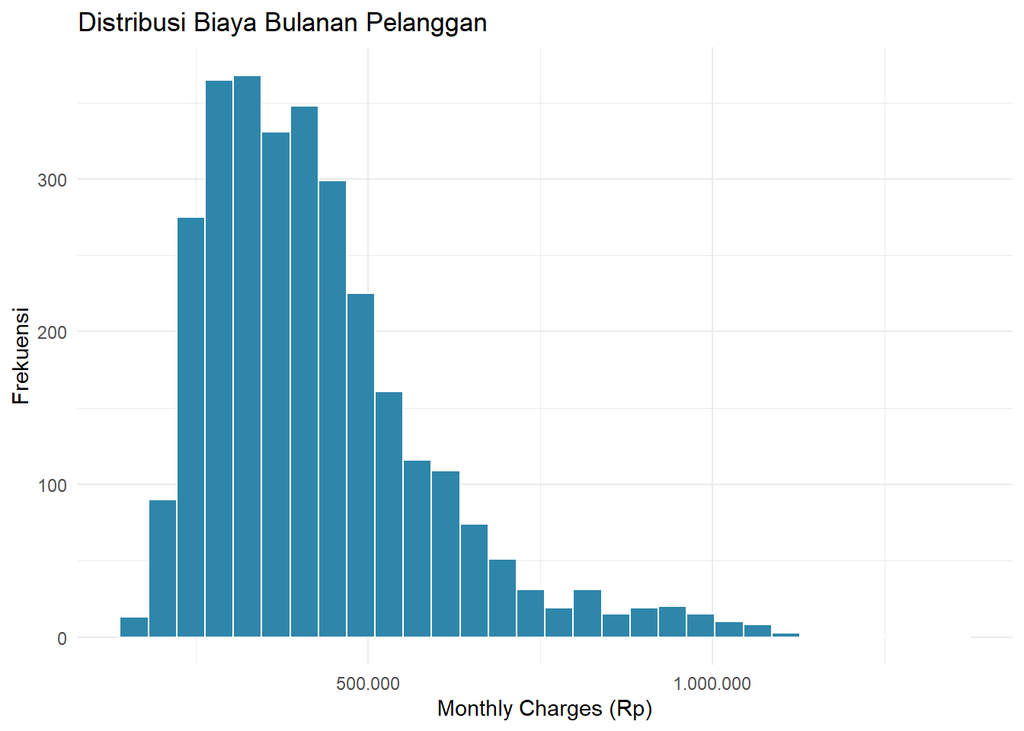

```r
ggplot(customer_churn,
       aes(x = monthly_charges)) +
  geom_histogram(
    bins = 30,
    fill = "#2E86AB",
    color = "white"
  ) +
  scale_x_continuous(labels = label_number(big.mark = ".")) +
  labs(
    title = "Distribusi Biaya Bulanan Pelanggan",
    x = "Monthly Charges (Rp)",
    y = "Frekuensi"
  ) +
  theme_minimal()
```

## 8.2 Distribusi Total Biaya

**Tampilkan / Sembunyikan Kode**

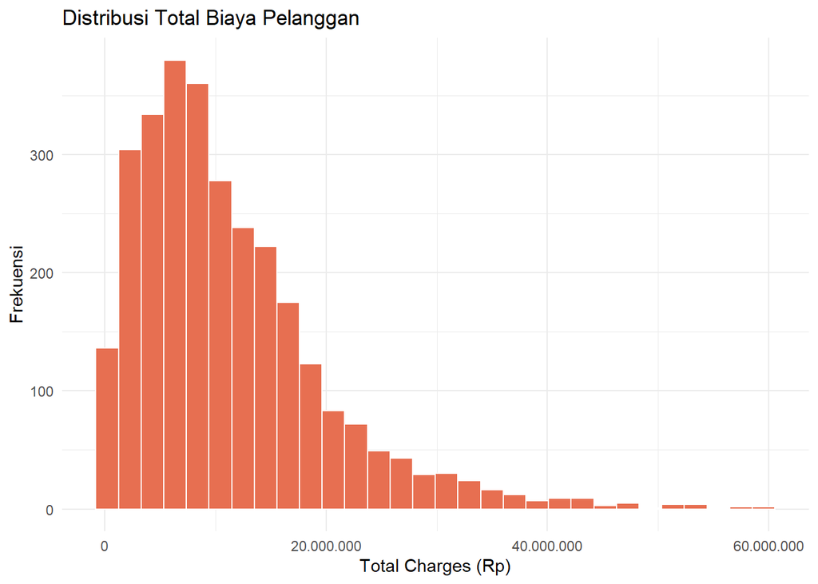

```r
ggplot(customer_churn,
       aes(x = total_charges)) +
  geom_histogram(
    bins = 30,
    fill = "#E76F51",
    color = "white",
    na.rm = TRUE
  ) +
  scale_x_continuous(labels = label_number(big.mark = ".")) +
  labs(
    title = "Distribusi Total Biaya Pelanggan",
    x = "Total Charges (Rp)",
    y = "Frekuensi"
  ) +
  theme_minimal()
```

## 8.3 Perbandingan Monthly Charges Berdasarkan Churn

**Tampilkan / Sembunyikan Kode**

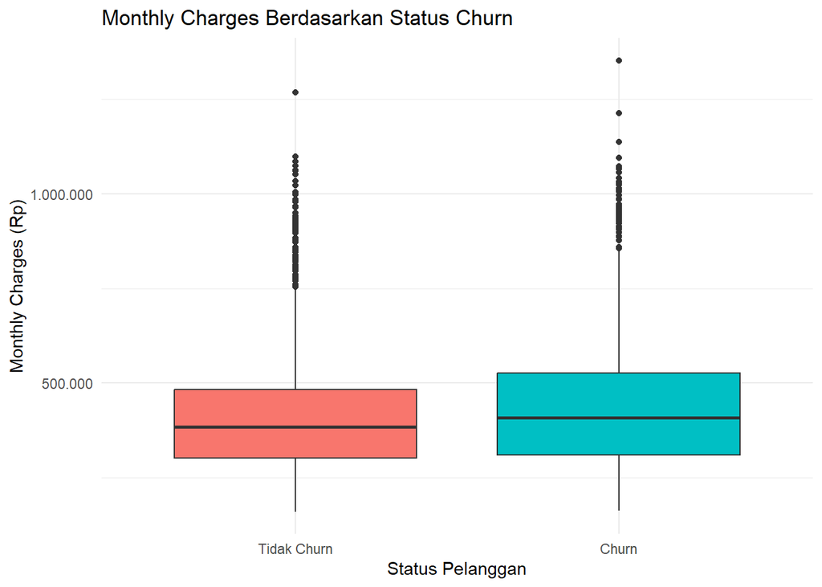

```r
ggplot(customer_churn,
       aes(x = churn, y = monthly_charges, fill = churn)) +
  geom_boxplot() +
  scale_y_continuous(labels = label_number(big.mark = ".")) +
  labs(
    title = "Monthly Charges Berdasarkan Status Churn",
    x = "Status Pelanggan",
    y = "Monthly Charges (Rp)"
  ) +
  theme_minimal() +
  theme(legend.position = "none")
```

## 8.4 Perbandingan Total Charges Berdasarkan Churn

**Tampilkan / Sembunyikan Kode**

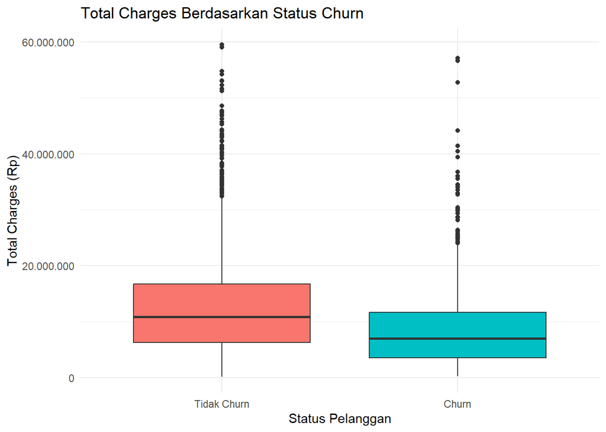

```r
ggplot(customer_churn,
       aes(x = churn, y = total_charges, fill = churn)) +
  geom_boxplot(na.rm = TRUE) +
  scale_y_continuous(labels = label_number(big.mark = ".")) +
  labs(
    title = "Total Charges Berdasarkan Status Churn",
    x = "Status Pelanggan",
    y = "Total Charges (Rp)"
  ) +
  theme_minimal() +
  theme(legend.position = "none")
```

## 8.5 Hubungan Monthly Charges dan Total Charges

**Tampilkan / Sembunyikan Kode**

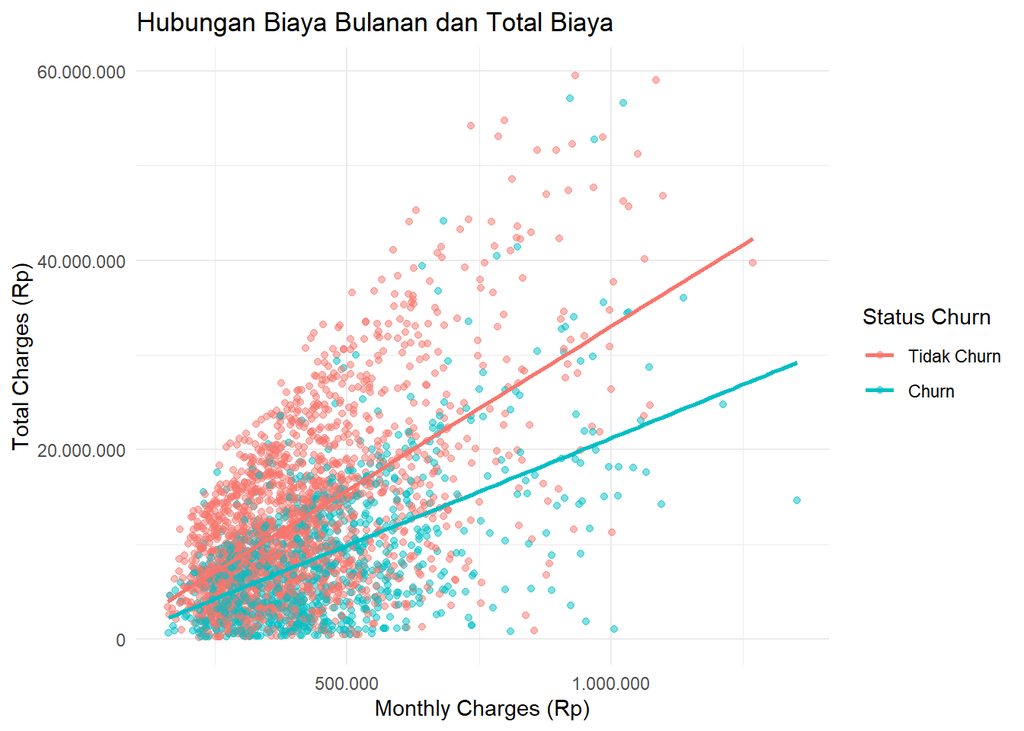

```r
ggplot(customer_churn,
       aes(x = monthly_charges,
           y = total_charges,
           color = churn)) +
  geom_point(alpha = 0.5, na.rm = TRUE) +
  geom_smooth(
    method = "lm",
    se = FALSE,
    na.rm = TRUE
  ) +
  scale_x_continuous(labels = label_number(big.mark = ".")) +
  scale_y_continuous(labels = label_number(big.mark = ".")) +
  labs(
    title = "Hubungan Biaya Bulanan dan Total Biaya",
    x = "Monthly Charges (Rp)",
    y = "Total Charges (Rp)",
    color = "Status Churn"
  ) +
  theme_minimal()
```

# 9 Customer Complaints and Support Analysis

Bagian ini menganalisis jumlah keluhan dan panggilan pelanggan kepada layanan customer support.

## 9.1 Distribusi Jumlah Keluhan

**Tampilkan / Sembunyikan Kode**

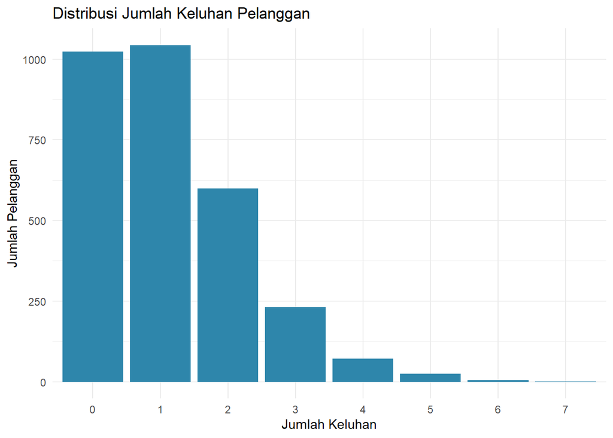

```r
ggplot(customer_churn,
       aes(x = factor(num_complaints))) +
  geom_bar(fill = "#2E86AB") +
  labs(
    title = "Distribusi Jumlah Keluhan Pelanggan",
    x = "Jumlah Keluhan",
    y = "Jumlah Pelanggan"
  ) +
  theme_minimal()
```

## 9.2 Jumlah Keluhan Berdasarkan Status Churn

**Tampilkan / Sembunyikan Kode**

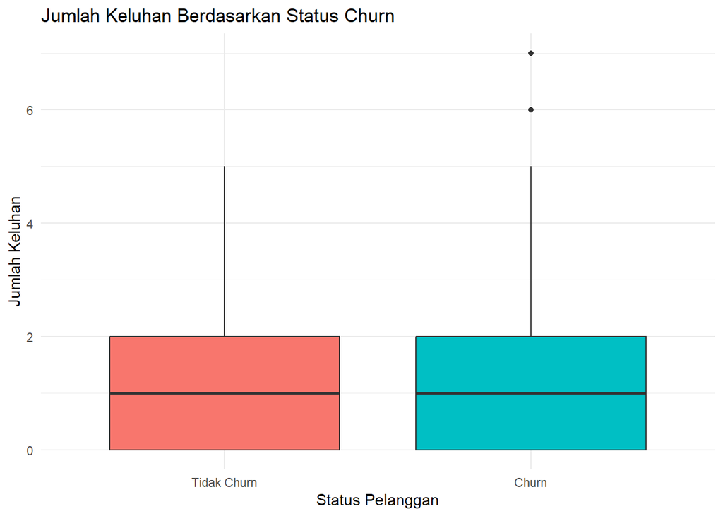

```r
ggplot(customer_churn,
       aes(x = churn, y = num_complaints, fill = churn)) +
  geom_boxplot() +
  labs(
    title = "Jumlah Keluhan Berdasarkan Status Churn",
    x = "Status Pelanggan",
    y = "Jumlah Keluhan"
  ) +
  theme_minimal() +
  theme(legend.position = "none")
```

## 9.3 Churn Rate Berdasarkan Jumlah Keluhan

**Tampilkan / Sembunyikan Kode**

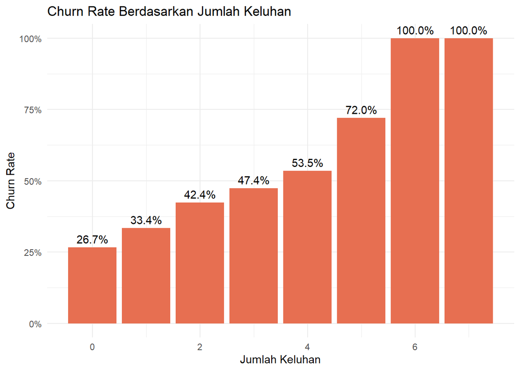

```r
complaint_churn <- customer_churn %>%
  group_by(num_complaints) %>%
  summarise(
    total_customer = n(),
    total_churn = sum(churn == "Churn"),
    churn_rate = total_churn / total_customer,
    .groups = "drop"
  )

ggplot(complaint_churn,
       aes(x = num_complaints, y = churn_rate)) +
  geom_col(fill = "#E76F51") +
  geom_text(
    aes(label = percent(churn_rate, accuracy = 0.1)),
    vjust = -0.5
  ) +
  scale_y_continuous(labels = percent) +
  labs(
    title = "Churn Rate Berdasarkan Jumlah Keluhan",
    x = "Jumlah Keluhan",
    y = "Churn Rate"
  ) +
  theme_minimal()
```

## 9.4 Distribusi Support Calls

**Tampilkan / Sembunyikan Kode**

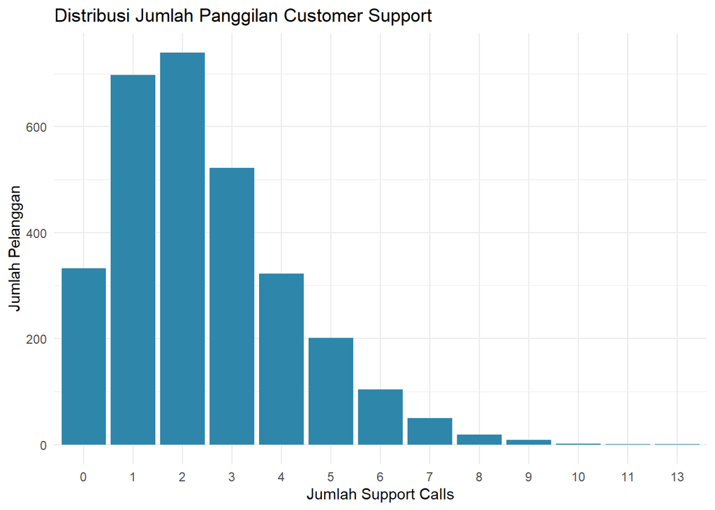

```r
ggplot(customer_churn,
       aes(x = factor(support_calls))) +
  geom_bar(fill = "#2E86AB") +
  labs(
    title = "Distribusi Jumlah Panggilan Customer Support",
    x = "Jumlah Support Calls",
    y = "Jumlah Pelanggan"
  ) +
  theme_minimal()
```

## 9.5 Support Calls Berdasarkan Status Churn

**Tampilkan / Sembunyikan Kode**

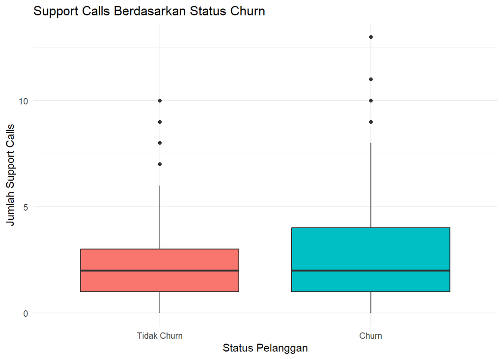

```r
ggplot(customer_churn,
       aes(x = churn, y = support_calls, fill = churn)) +
  geom_boxplot() +
  labs(
    title = "Support Calls Berdasarkan Status Churn",
    x = "Status Pelanggan",
    y = "Jumlah Support Calls"
  ) +
  theme_minimal() +
  theme(legend.position = "none")
```